# Public Health and Economic Impact of Natural Disasters in the United States

# Results

One way to visualize the economic loss by storm event types was to build an interactive table with both total property damage and total crop damage columns. You can sort or filter table as desired and by keeping total number of storm events in the table get a sense of overall cost per event. From this table we realize that some storm event types are more detrimental for property loss and others for crop loss.

Storm event types like Flooding, Tornados, Hail, and Thunderstorms seem more prevalent across reporting period with high numbers of event and large economic losses, whereas events like Hurricane-Typhoon, Storm Surge-Tide Related, and Drought events do not have as many events but still show up as heavy economic losses.

```r
datatable(df.summary.total, rownames = FALSE, filter="top", options=list(pageLength=30)) %>%
    formatCurrency(c("Total.Property.Damage", "Total.Crop.Damage"), "$")
```

| Storm.Event.Type | Number.Events | Total.Property.Damage | Total.Crop.Damage |
| --- | --- | --- | --- |
| Blizzard | 256 | 659363950 | 112060000 |
| Cold Related | 499 | 246334450 | 1433765550 |
| Drought Related | 357 | 1053038600 | 13972636780 |
| Dust Storm | 269 | 16053930 | 3100000 |
| Flooding | 33153 | 167561215320 | 12270394200 |
| Freezing Rain-Sleet-Wintery Mix | 28 | 3644500 | 0 |
| Frost-Freeze | 155 | 19200000 | 1997061000 |
| Hail | 26673 | 17620319290 | 3114214850 |
| Heat Related | 978 | 20125750 | 904423500 |
| High Surf or Rip Current | 880 | 101653500 | 0 |

[output cut: 16 more lines]

I constructed a second table with Mean and Median Property and Crop Damage columns to better understand economic loss by storm event type. This table is also sortable and filterable to help user better understand the relationships between storm event type, number of events, and economic loss.

When evaluating property loss events it seems the most costly events on a median or mean basis are not as common, but when an event occurs it provides a huge economic loss of property. Crop damage is a little more confusing, as median crop loss is often 0 which means while many storm events may occur, most do not damage the farmers economically (lots of $0 loss events). However, when an event occurs and there is crop economic loss, it tends to be a big number.

```r
datatable(df.summary.stats, rownames = FALSE, filter="top", options=list(pageLength=30)) %>%
    formatCurrency(c("Median.Property.Damage", "Average.Property.Damage",
                     "Median.Crop.Damage", "Average.Crop.Damage"), "$")
```

| Storm.Event.Type | Number.Events | Median.Property.Damage | Average.Property.Damage | Median.Crop.Damage | Average.Crop.Damage |
| --- | --- | --- | --- | --- | --- |
| Blizzard | 256 | 77500 | 2575640 | 0 | 437734 |
| Cold Related | 499 | 0 | 493656 | 0 | 2873278 |
| Drought Related | 357 | 0 | 2949688 | 250000 | 39139039 |
| Dust Storm | 269 | 5000 | 59680 | 0 | 11524 |
| Flooding | 33153 | 25000 | 5054180 | 0 | 370114 |
| Freezing Rain-Sleet-Wintery Mix | 28 | 20000 | 130161 | 0 | 0 |
| Frost-Freeze | 155 | 0 | 123871 | 1000000 | 12884265 |
| Hail | 26673 | 5000 | 660605 | 0 | 116755 |
| Heat Related | 978 | 0 | 20578 | 0 | 924768 |
| High Surf or Rip Current | 880 | 0 | 115515 | 0 | 0 |

[output cut: 16 more lines]

To understand the prevalance of human loss, a table was constructed to split out both fatalities and injuries for each storm event type across the reporting period. Again we see some similar patterns with the number of events and either fatalities or injuries, but it is quite noticeable that Tornado events cause high numbers of fatalities and injuries although this could be an artifact of the dataset only including tornado events before 1956 and limited other events from 1956-1996. A more robust analysis for loss may want to focus on the 1996-current dataset.

```r
datatable(df.summary.humans, rownames=FALSE, filter="top", options=list(pageLength=30))
```

| Storm.Event.Type | Number.Events | Total.Fatalities | Total.Injuries |
| --- | --- | --- | --- |
| Blizzard | 256 | 101 | 805 |
| Cold Related | 499 | 468 | 325 |
| Drought Related | 357 | 38 | 48 |
| Dust Storm | 269 | 27 | 515 |
| Flooding | 33153 | 1556 | 8681 |
| Freezing Rain-Sleet-Wintery Mix | 28 | 6 | 92 |
| Frost-Freeze | 155 | 2 | 3 |
| Hail | 26673 | 45 | 1467 |
| Heat Related | 978 | 3144 | 9228 |
| High Surf or Rip Current | 880 | 752 | 790 |

[output cut: 16 more lines]

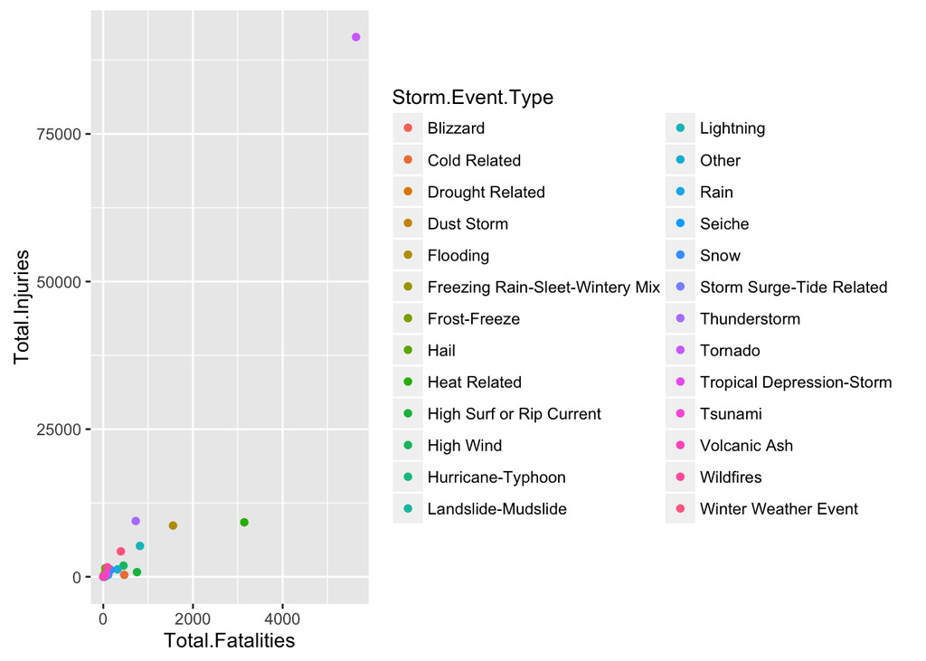

```r
ggplot(df.summary.humans, aes(Total.Fatalities, Total.Injuries, colour=Storm.Event.Type)) + geom_point()
```

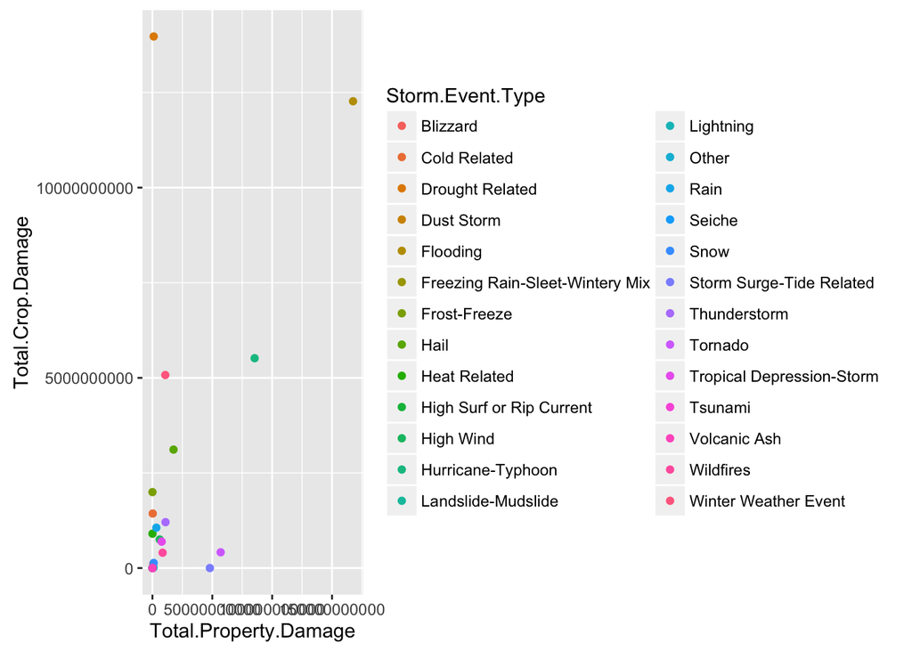

```r
ggplot(df.summary.total, aes(Total.Property.Damage, Total.Crop.Damage, colour=Storm.Event.Type)) +geom_point()
```

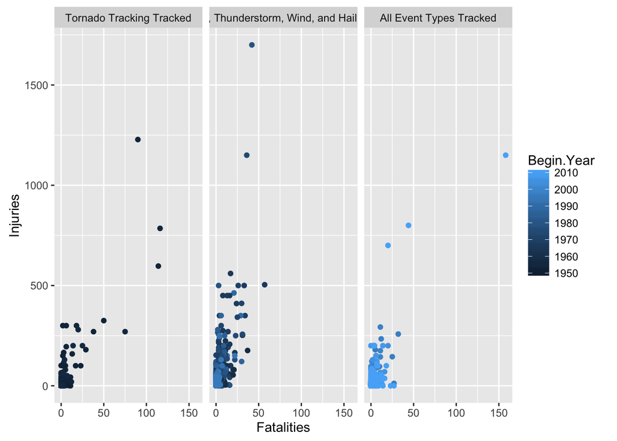

```r
df.tornado <- df %>%
    filter(Storm.Event.Type=="Tornado")

ggplot(df.tornado, aes(Fatalities, Injuries, colour=Begin.Year)) + geom_point() + facet_grid(. ~ x)
```